# Arrival and Departure Final Models with Traits Included

```r
#save this table
saveRDS(arrival_model_comparisons_traits.lag9max, file = "Col_Ext/Model_results/arrival_models_traits_with_likelihoods.rds")
```

```r
arrival_departure <- c("arrival","arrival","arrival","arrival","arrival", "arrival","arrival", "arrival", "arrival","arrival", "arrival","arrival", "arrival", "arrival","arrival")
type <- c("depth", "depth", "lag", "lag", "Change?", "Change?", "Change?", "Temp", "Temp", "Temp", "Trait", "Trait", "Trait","Trait", "Interaction")
variable <- c("bottom", "surface", "no_lag", "lagged", "absolute_value_change", "change", "raw", "Min", "Max", "Seas", "age.max", "age.maturity", "tl", "length.max", "tempxtrait")
value <- c(arrival_bottom_importance, arrival_surface_importance, arrival_nolag_importance, arrival_lag_importance, arrival_abs_importance, arrival_change_importance, arrival_raw_importance, arrival_min_temp_importance, arrival_max_temp_importance, arrival_seas_temp_importance, arrival_age.max_importance, arrival_age.maturity_importance, arrival_tl_importance, arrival_length.max_importance, arrival_interaction_temp_trait_importance)

RVI_arrival_traits <- data.table(arrival_departure, type, variable, value)
```

Departure

```r
#only raw temp has lag of 10 years, which means variable importance comparisons are unbalanced so I will get rid of these rows
departure_model_comparisons_traits.lag9max <- departure_model_comparison_traits[!grepl("lag10", temp_variable), ]


#add ∆AIC to tables
min_departure_AICc_trait <- min(departure_model_comparisons_traits.lag9max[, AICc])
departure_model_comparisons_traits.lag9max[,"deltaAICc" := (AICc - min_departure_AICc_trait)]

#add relative likelihood exp( -0.5 * ∆AIC score for that model)
departure_model_comparisons_traits.lag9max[,"rel_likelihood" := exp((-0.5 * deltaAICc))]
#sum relative likelihoods across all models
departure_model_comparisons_traits.lag9max.likelihoodsum <- sum(departure_model_comparisons_traits.lag9max[, rel_likelihood])
#Akaike weight for a model is this rel_likelihood devided by the sum of these values across all models
departure_model_comparisons_traits.lag9max[,"akaike_weight" := rel_likelihood/departure_model_comparisons_traits.lag9max.likelihoodsum]

#I want to look at relative importance FOR
#bottom/surface (bottom = includes sbt, grepl("sbt", variable))
departure_bottom_importance <- sum(departure_model_comparisons_traits.lag9max[grep("sbt", temp_variable), ]$akaike_weight)
  departure_bottom_importance.n <- count(departure_model_comparisons_traits.lag9max[grepl("sbt", temp_variable), ]) #3060
departure_surface_importance <- sum(departure_model_comparisons_traits.lag9max[grep("sst", temp_variable), ]$akaike_weight)
  departure_surface_importance.n <- count(departure_model_comparisons_traits.lag9max[grepl("sst", temp_variable), ]) #3060

#lag/not lagged (grepl("lag", variable))
departure_lag_importance <- sum(departure_model_comparisons_traits.lag9max[grep("lag", temp_variable), ]$akaike_weight)
  departure_lag_importance.n <- count(departure_model_comparisons_traits.lag9max[grepl("lag", temp_variable),]) #5508
departure_nolag_importance <- sum(departure_model_comparisons_traits.lag9max[!grep("lag", temp_variable), ]$akaike_weight)
  departure_nolag_importance.n <- count(departure_model_comparisons_traits.lag9max[!grepl("lag", temp_variable), ]) #646

  #absolute (grepl("abs", variable))
departure_abs_importance <- sum(departure_model_comparisons_traits.lag9max[grep("abs", temp_variable), ]$akaike_weight)
  departure_abs_importance.n <- count(departure_model_comparisons_traits.lag9max[grepl("abs", temp_variable), ]) #2040

  #raw (!grepl("change"))
departure_raw_importance <- sum(departure_model_comparisons_traits.lag9max[!grep("change", temp_variable), ][temp_variable != 0,]$akaike_weight)
  departure_raw_importance.n <- count(departure_model_comparisons_traits.lag9max[!grepl("change", temp_variable), ][temp_variable != 0,]) #2040

#change (grepl("change", temp_variable), (!grepl("abs")))
departure_change_importance <- sum(departure_model_comparisons_traits.lag9max[grep("change", temp_variable), ][!grep("abs", temp_variable),]$akaike_weight)
  departure_change_importance.n <- count(departure_model_comparisons_traits.lag9max[grepl("change", temp_variable), ][!grepl("abs", temp_variable),])#2040

#type of temp temp_variable (max, min, seas)
departure_max_temp_importance <- sum(departure_model_comparisons_traits.lag9max[grep("max", temp_variable), ]$akaike_weight)
  departure_max_temp_importance.n <- count(departure_model_comparisons_traits.lag9max[grepl("max", temp_variable), ]) #2040
departure_min_temp_importance <- sum(departure_model_comparisons_traits.lag9max[grep("min", temp_variable), ]$akaike_weight)
  departure_min_temp_importance.n <- count(departure_model_comparisons_traits.lag9max[grepl("min", temp_variable), ]) #2040
departure_seas_temp_importance <- sum(departure_model_comparisons_traits.lag9max[grep("seas", temp_variable), ]$akaike_weight)
  departure_seas_temp_importance.n <- count(departure_model_comparisons_traits.lag9max[grepl("seas", temp_variable), ]) #2040

#traits included
departure_age.max_importance <- sum(departure_model_comparisons_traits.lag9max[grep("age.max", trait_variable), ]$akaike_weight)
departure_age.maturity_importance <- sum(departure_model_comparisons_traits.lag9max[grep("age.maturity", trait_variable), ]$akaike_weight)
departure_tl_importance <- sum(departure_model_comparisons_traits.lag9max[grep("tl", trait_variable), ]$akaike_weight)
departure_length.max_importance <- sum(departure_model_comparisons_traits.lag9max[grep("length", trait_variable),]$akaike_weight)

  departure_age.max_importance.n <- count(departure_model_comparisons_traits.lag9max[grepl("age.max", trait_variable), ]) #2534
  departure_age.maturity_importance.n <- count(departure_model_comparisons_traits.lag9max[grepl("age.maturity", trait_variable), ]) #2534
  departure_tl_importance.n <- count(departure_model_comparisons_traits.lag9max[grepl("tl", trait_variable), ]) #2534
  departure_length.max_importance.n <- count(departure_model_comparisons_traits.lag9max[grepl("length", trait_variable),]) #2534

#interaction between trait and temperature
departure_interaction_temp_trait_importance <- sum(departure_model_comparisons_traits.lag9max[grep("\\*", sign), ]$akaike_weight)
  departure_interaction_temp_trait_importance.n <- count(departure_model_comparisons_traits.lag9max[grepl("\\*", sign), ]) #3077


#save this table
#save this table
saveRDS(departure_model_comparisons_traits.lag9max, here::here("Model_results","Traits","departure_model_comparisons_traits.lag9max.rds"))
```

```r
arrival_departure <- c("departure","departure","departure","departure","departure", "departure","departure", "departure", "departure","departure", "departure","departure", "departure", "departure","departure")
type <- c("depth", "depth", "lag", "lag", "Change?", "Change?", "Change?", "Temp", "Temp", "Temp", "Trait", "Trait", "Trait","Trait", "Interaction")
variable <- c("bottom", "surface", "no_lag", "lagged", "absolute_value_change", "change", "raw", "Min", "Max", "Seas", "age.max", "age.maturity", "tl", "length.max", "tempxtrait")
value <- c(departure_bottom_importance, departure_surface_importance, departure_nolag_importance, departure_lag_importance, departure_abs_importance, departure_change_importance, departure_raw_importance, departure_min_temp_importance, departure_max_temp_importance, departure_seas_temp_importance, departure_age.max_importance, departure_age.maturity_importance, departure_tl_importance, departure_length.max_importance, departure_interaction_temp_trait_importance)

RVI_departure_traits <- data.table(arrival_departure, type, variable, value)
```

Merge RVI tables for colonization and extinction with traits, and then graph

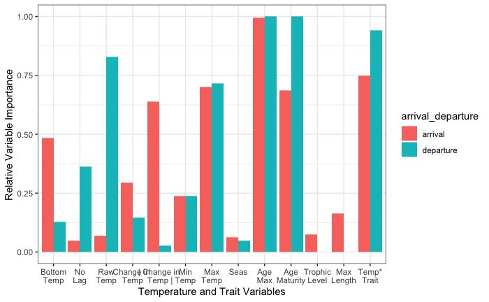

#START HERE ONCE I ACTUALLY RUN CODE ABOVE

Another way to visualize

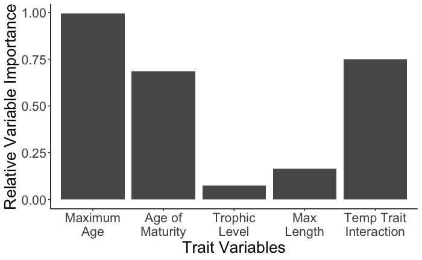

```r
#put levels into correct order for viewing
RVI_trait_table[
  , variable := factor(variable, levels = c("bottom", "surface", "absolute_value_change", "change", "raw", "no_lag", "lagged", "Min", "Max", "Seas", "age.max", "age.maturity", "tl","length.max", "tempxtrait"))][
    ,type := factor(type, levels = c("Change?", "depth", "lag", "Temp", "Trait", "Interaction"))]
#make types factors as well

#colonization
RVI_col_trait_plot <- ggplot(data = RVI_trait_table[arrival_departure == "arrival" & (type == "Trait" | type == "Interaction")], aes(x=variable, y = value)) +
  geom_bar(stat= "identity") +
  scale_x_discrete(breaks = c("age.max", "age.maturity", "tl", "length.max", "tempxtrait"), labels = c("Maximum\nAge", "Age of\nMaturity", "Trophic\nLevel","Max\nLength", "Temp Trait\nInteraction")) +
  labs(x = "Trait Variables", y = "Relative Variable Importance") +
  theme_classic() +
  theme(text = element_text(size = 20))
#extinction
RVI_ext_trait_plot <- ggplot(data = RVI_trait_table[arrival_departure == "departure" & (type == "Trait" | type == "Interaction")], aes(x=variable, y = value)) +
  geom_bar(stat= "identity") +
  scale_x_discrete(breaks = c("age.max", "age.maturity", "tl","length.max",  "tempxtrait"), labels = c("Maximum\nAge", "Age of\nMaturity", "Trophic\nLevel","Max\nLength", "Temp Trait\nInteraction")) +
  labs(x = "Trait Variables", y = "Relative Variable Importance") +
  theme_classic() +
  theme(text = element_text(size = 20))

RVI_col_trait_plot
```

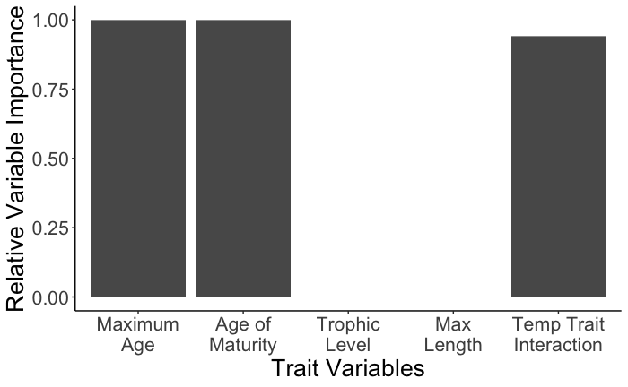

```r
RVI_ext_trait_plot
```

```r
save(RVI_trait_table, file = "RVI_trait_table.Rdata")
```

Let’s see how the RVI importance varies by looking at specific lag values for these trait models

```r
#first, table for lags
lags_v_RVI_trait <- data.table(col_lag = c(0:9), col_RVI = 0, ext_RVI = 0)
#arrival
lags_v_RVI_trait[1,2] <- 1-sum(arrival_model_comparisons_traits.lag9max[grep("lag", temp_variable), ]$akaike_weight)
lags_v_RVI_trait[2,2] <- sum(arrival_model_comparisons_traits.lag9max[grep("lag1", temp_variable), ]$akaike_weight)
lags_v_RVI_trait[3,2] <- sum(arrival_model_comparisons_traits.lag9max[grep("lag2", temp_variable), ]$akaike_weight)
lags_v_RVI_trait[4,2] <- sum(arrival_model_comparisons_traits.lag9max[grep("lag3", temp_variable), ]$akaike_weight)
lags_v_RVI_trait[5,2] <- sum(arrival_model_comparisons_traits.lag9max[grep("lag4", temp_variable), ]$akaike_weight)
lags_v_RVI_trait[6,2] <- sum(arrival_model_comparisons_traits.lag9max[grep("lag5", temp_variable), ]$akaike_weight)
lags_v_RVI_trait[7,2] <- sum(arrival_model_comparisons_traits.lag9max[grep("lag6", temp_variable), ]$akaike_weight)
lags_v_RVI_trait[8,2] <- sum(arrival_model_comparisons_traits.lag9max[grep("lag7", temp_variable), ]$akaike_weight)
lags_v_RVI_trait[9,2] <- sum(arrival_model_comparisons_traits.lag9max[grep("lag8", temp_variable), ]$akaike_weight)
lags_v_RVI_trait[10,2] <- sum(arrival_model_comparisons_traits.lag9max[grep("lag9", temp_variable), ]$akaike_weight)
#departure
lags_v_RVI_trait[1,3] <- 1-sum(departure_model_comparisons_traits.lag9max[grep("lag", temp_variable), ]$akaike_weight)
lags_v_RVI_trait[2,3] <- sum(departure_model_comparisons_traits.lag9max[grep("lag1", temp_variable), ]$akaike_weight)
lags_v_RVI_trait[3,3] <- sum(departure_model_comparisons_traits.lag9max[grep("lag2", temp_variable), ]$akaike_weight)
lags_v_RVI_trait[4,3] <- sum(departure_model_comparisons_traits.lag9max[grep("lag3", temp_variable), ]$akaike_weight)
lags_v_RVI_trait[5,3] <- sum(departure_model_comparisons_traits.lag9max[grep("lag4", temp_variable), ]$akaike_weight)
lags_v_RVI_trait[6,3] <- sum(departure_model_comparisons_traits.lag9max[grep("lag5", temp_variable), ]$akaike_weight)
lags_v_RVI_trait[7,3] <- sum(departure_model_comparisons_traits.lag9max[grep("lag6", temp_variable), ]$akaike_weight)
lags_v_RVI_trait[8,3] <- sum(departure_model_comparisons_traits.lag9max[grep("lag7", temp_variable), ]$akaike_weight)
lags_v_RVI_trait[9,3] <- sum(departure_model_comparisons_traits.lag9max[grep("lag8", temp_variable), ]$akaike_weight)
lags_v_RVI_trait[10,3] <- sum(departure_model_comparisons_traits.lag9max[grep("lag9", temp_variable), ]$akaike_weight)

RVI_lags_traits <- ggplot(data = lags_v_RVI_trait, aes(x = col_lag)) +
  geom_line(aes(y = col_RVI)) +
  geom_line(aes(y = ext_RVI), linetype = "dashed") +
  labs(x = "Lag (years)", y = "Relative Variable Importance") +
  theme_classic() +
  theme(text = element_text(size = 22, color = "black")) +
  scale_x_continuous(breaks = 0:10) +
  scale_y_continuous(limits = 0:1)

save(RVI_col_trait_plot, RVI_ext_trait_plot, RVI_lags_traits, file = "RVI_plots_traits.Rdata")

setEPS()
postscript("RVI_col_trait_plot.eps")
RVI_col_trait_plot
dev.off()
```

```r
setEPS()
postscript("RVI_ext_trait_plot.eps")
```

```r
RVI_ext_trait_plot
dev.off()
```

```r
setEPS()
postscript("RVI_lags_trait_plot.eps")
```

```r
RVI_lags_traits
dev.off()
```

What do interactions look like?

##Colonization with Traits Best model: max_sst_temp_change_abs_lag1_scaled * age.maturity_ocean_scaled + age.max_ocean_scaled Best model with all species: seas_sst_temp_scaled * age.maturity_ocean_scaled + age.max_ocean_scaled

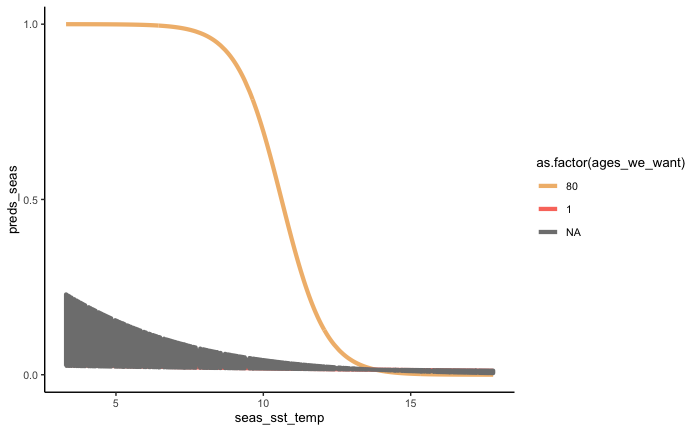

##Extinction with Traits Best model: max_sst_temp_scaled * age.maturity_ocean_scaled + age.max_ocean_scaled Best model from analyses with temperature only: seas_sst_temp_lag3_scaled

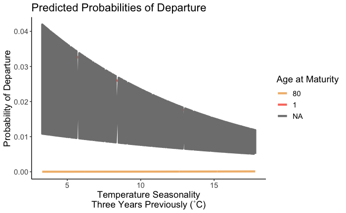

Merge marginal effects plots

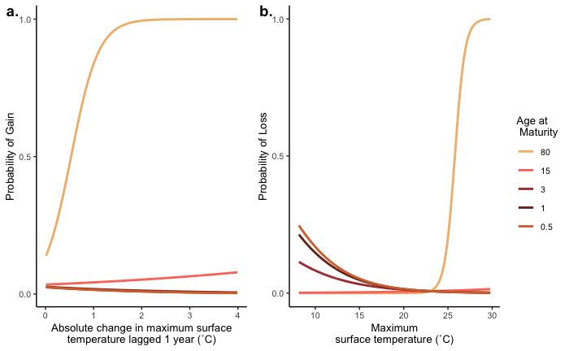